# Retail Forecasting Project

Jie Heng Yu

11/11/2023

# Retail Forecasting Project

### Data Preparation

We save our read data to variable `retailDF`. The data is prepared by renaming columns, recoding the columns, & searching for missing values/outliers. We will keep outliers in our dataset because they are representations of the population-level observation. Also, the company’s product demand is influenced by factors such as holidays & seasonality, so I want to make sure that these extreme outliers are accounted for & explained.

```r
retailDF <- as_tibble(read.csv('ForecastingCaseStudy.csv'))
head(retailDF)
```

```
## # A tibble: 6 × 12
##   Product date      Sales Price.Discount.... In.Store.Promo Catalogue.Promo
##   <chr>   <chr>     <int> <chr>                       <int>           <int>
## 1 SKU1    2/5/2017  27750 0%                              0               0
## 2 SKU1    2/12/2017 29023 0%                              1               0
## 3 SKU1    2/19/2017 45630 17%                             0               0
## 4 SKU1    2/26/2017 26789 0%                              1               0
## 5 SKU1    3/5/2017  41999 17%                             0               0
## 6 SKU1    3/12/2017 29731 0%                              0               0
## # ℹ 6 more variables: Store.End.Promo <int>, Google_Mobility <dbl>,
## #   Covid_Flag <int>, V_DAY <int>, EASTER <int>, CHRISTMAS <int>
```

```r
# Look for missing data
colSums(is.na(retailDF))
```

```
##            Product               date              Sales Price.Discount....
##                  0                  0                  0                  0
##     In.Store.Promo    Catalogue.Promo    Store.End.Promo    Google_Mobility
##                  0                  0                  0                  0
##         Covid_Flag              V_DAY             EASTER          CHRISTMAS
##                  0                  0                  0                  0
```

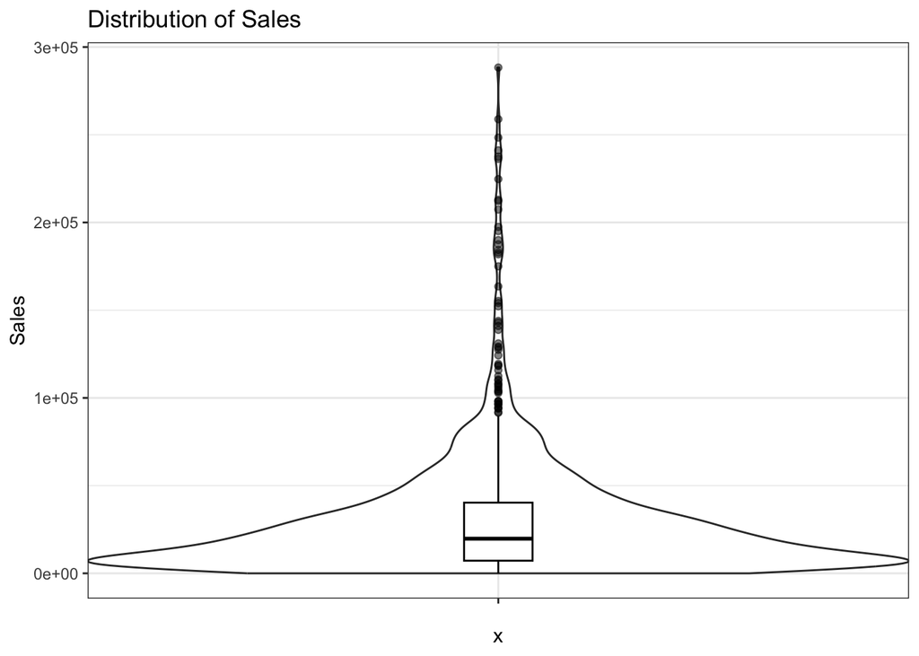

```r
# Look for outliers
ggplot(retailDF, aes(x = '', y = Sales)) +
  geom_violin(width = 1.2) +
  geom_boxplot(width = 0.1, color = 'black', alpha = 0.5) +
  theme_bw() +
  labs(title = 'Distribution of Sales')
```

```r
# Rename columns
colnames(retailDF)[4] <- 'Price.Discount(%)'
colnames(retailDF)[10:12] <- c('Valentines Day', 'Easter', 'Christmas')
# Recode date times to week year
retailDF$date <- as.Date(retailDF$date, '%m/%d/%Y')
retailDF <- mutate(retailDF, Week = isoweek(ymd(retailDF$date)), Year = isoyear(ymd(retailDF$date)))
# Remove % from Price Discount (%)
retailDF$`Price.Discount(%)` <- as.numeric(str_remove(retailDF$`Price.Discount(%)`, '%'))
# Remove date column
retailDF <- select(retailDF, -date)
# Recode products column to be numeric
retailDF$Product <- recode(retailDF$Product, 'SKU1' = 1, 'SKU2' = 2, 'SKU3' = 3, 'SKU4' = 4, 'SKU5' = 5, 'SKU6' = 6)
retailDF
```

```
## # A tibble: 1,218 × 13
##    Product Sales `Price.Discount(%)` In.Store.Promo Catalogue.Promo
##      <dbl> <int>               <dbl>          <int>           <int>
##  1       1 27750                   0              0               0
##  2       1 29023                   0              1               0
##  3       1 45630                  17              0               0
##  4       1 26789                   0              1               0
##  5       1 41999                  17              0               0
##  6       1 29731                   0              0               0
##  7       1 27365                   0              1               0
##  8       1 27722                   0              1               0
##  9       1 44339                  17              1               0
## 10       1 54655                  17              1               0
## # ℹ 1,208 more rows
## # ℹ 8 more variables: Store.End.Promo <int>, Google_Mobility <dbl>,
## #   Covid_Flag <int>, `Valentines Day` <int>, Easter <int>, Christmas <int>,
## #   Week <dbl>, Year <dbl>
```